# Interacting with APIs: Example with finacial data

Ningning Zhang

10/4/2021

```r
rmarkdown::render(input="C:/Users/info/OneDrive/Desktop/U Drive-01Feb2019/NZ/ST558/Project-1/project-1", output_format = github_document)
```

## Load in packages

```r
# load in the packages.
library(tidyverse)
library(jsonlite)
library(cowplot)
library(imager)
library(broom)
library(RCurl)
library(httr)
```

## API interaction functions

### Here we drew the stock price of APPLE from 1999-01-01 to 2021-09-30 from website [polygon] (https://polygon.io/docs/getting-started). The users may update the date and ticker names, range.

```r
#get data from API
apple <- GET("https://api.polygon.io/v2/aggs/ticker/AAPL/range/1/day/1999-01-01/2021-09-30?apiKey=5xypYpHq6qD3InDjLOiwTM16yogYvmgE")
applStock <-apple$content %>% rawToChar() %>% fromJSON()
applStock_df <- as.data.frame(applStock)
#drop columns
applStock_df$queryCount <-NULL
applStock_df$resultsCount <-NULL
applStock_df$adjusted <-NULL
applStock_df$status <-NULL
applStock_df$request_id <-NULL
applStock_df$count <-NULL
applStock_df$results.n <-NULL
applStock_df$results.t <-NULL
#rename columns
colnames(applStock_df) <- c("tiker", "volume", "v.weighted avg price", "open", "close", "highest", "lowest")
```

### Here we drew the stock price of Facebook from 1999-01-01 to 2021-09-30.

```r
#get data from API
fb <- GET("https://api.polygon.io/v2/aggs/ticker/FB/range/1/day/1999-01-01/2021-09-30?apiKey=5xypYpHq6qD3InDjLOiwTM16yogYvmgE")
fbStock <-fb$content %>% rawToChar() %>% fromJSON()
fbStock_df <- as.data.frame(fbStock)
#drop columns
fbStock_df$queryCount <-NULL
fbStock_df$resultsCount <-NULL
fbStock_df$adjusted <-NULL
fbStock_df$status <-NULL
fbStock_df$request_id <-NULL
fbStock_df$count <-NULL
fbStock_df$results.n <-NULL
fbStock_df$results.t <-NULL
#rename columns
colnames(fbStock_df) <- c("tiker", "volume", "v.weighted avg price", "open", "close", "highest", "lowest")
```

## Data exploration

```r
tabAPPL <-data.frame(table(applStock_df$tiker, applStock_df$highest))
colnames(tabAPPL) <- c("Tiker", "Highest price", "Frequency")
```

```r
tabFB <-data.frame(table(fbStock_df$tiker, fbStock_df$highest))
colnames(tabFB) <- c("Tiker", "Highest price", "Frequency")
```

### Create numeric tables

```r
summary(applStock_df$`v.weighted avg price`)
```

```
##    Min. 1st Qu.  Median    Mean 3rd Qu.    Max.
##   55.35   78.10  116.17  106.75  130.04  156.18
```

```r
var(applStock_df$`v.weighted avg price`)
```

```
## [1] 857.0764
```

```r
sd(applStock_df$`v.weighted avg price`)
```

```
## [1] 29.27587
```

```r
cor(applStock_df$`v.weighted avg price`, applStock_df$volume)## no linear relationship between Apple stock volume and price.
```

```
## [1] -0.3786895
```

```r
summary(fbStock_df$`v.weighted avg price`)
```

```
##    Min. 1st Qu.  Median    Mean 3rd Qu.    Max.
##   142.8   210.7   263.1   261.1   299.8   382.2
```

```r
var(fbStock_df$`v.weighted avg price`)
```

```
## [1] 3402.264
```

```r
sd(fbStock_df$`v.weighted avg price`)
```

```
## [1] 58.32893
```

```r
cor(fbStock_df$`v.weighted avg price`, fbStock_df$volume)## no linear relationship between Facebook stock volume and price.
```

```
## [1] -0.1947107
```

### Create plots for the two endpoints from financial data.

I am curious about the difference between highest and lowest price (diff1), also the difference between close and open price (diff2).

```r
diff1_APPL <- applStock_df %>% mutate(diff1=abs(highest-lowest))
applStock_df <- diff1_APPL %>% mutate(diff2=abs(close-open))
```

```r
diff1_FB <- fbStock_df %>% mutate(diff1=abs(highest-lowest))
fbStock_df <- diff1_FB %>% mutate(diff2=abs(close-open))
```

### Create the histogram for Apple stock and FB stock prices.

Make a histogram of Apple stock absolute difference between highest and lowest price.

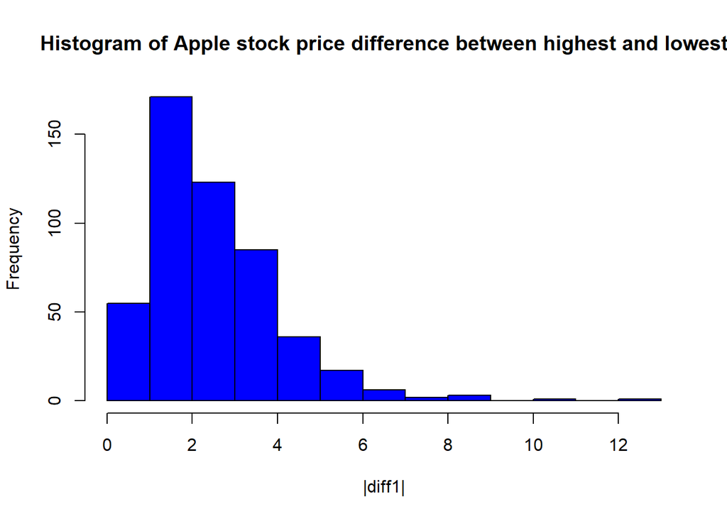

```r
hist(applStock_df$diff1, main = paste("Histogram of Apple stock price difference between highest and lowest"), xlab = "|diff1|", col = "blue")
```

Make a histogram of Apple stock absolute difference between open and close price.

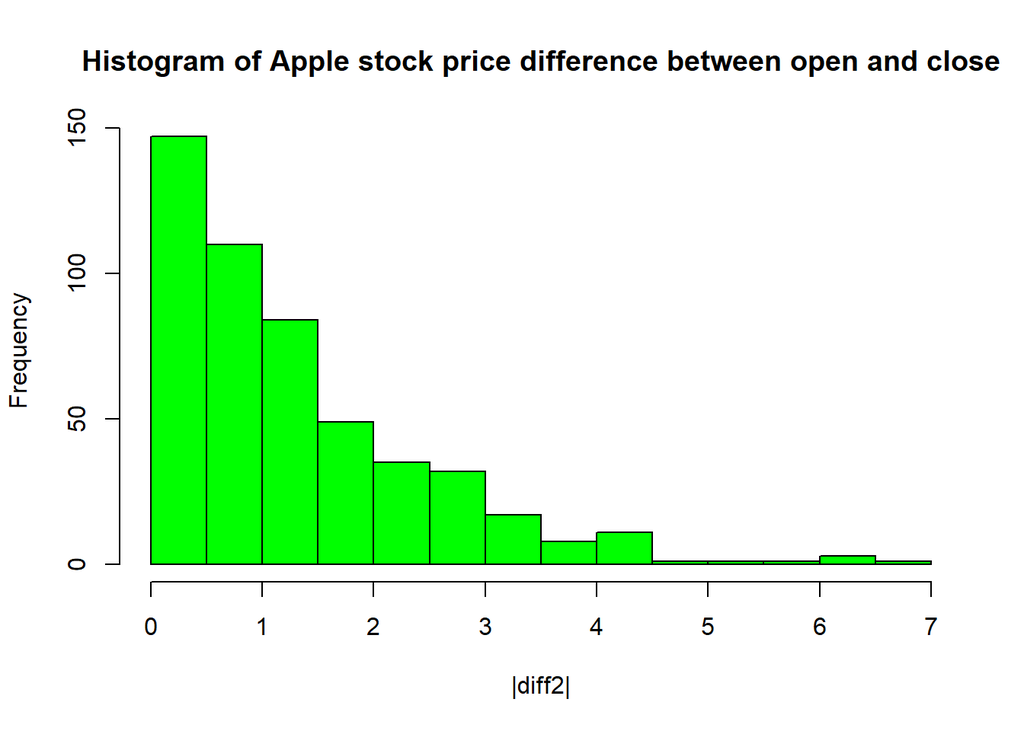

```r
hist(applStock_df$diff2, main = paste("Histogram of Apple stock price difference between open and close"), xlab = "|diff2|", col = "green")
```

Make a histogram of FB stock absolute difference between highest and lowest price.

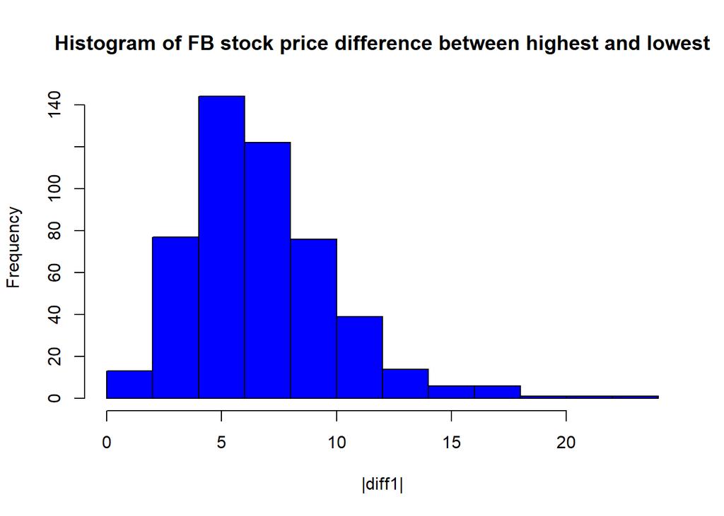

```r
hist(fbStock_df$diff1, main = paste("Histogram of FB stock price difference between highest and lowest"), xlab = "|diff1|", col = "blue")
```

Make a histogram of FB stock absolute difference between open and close price.

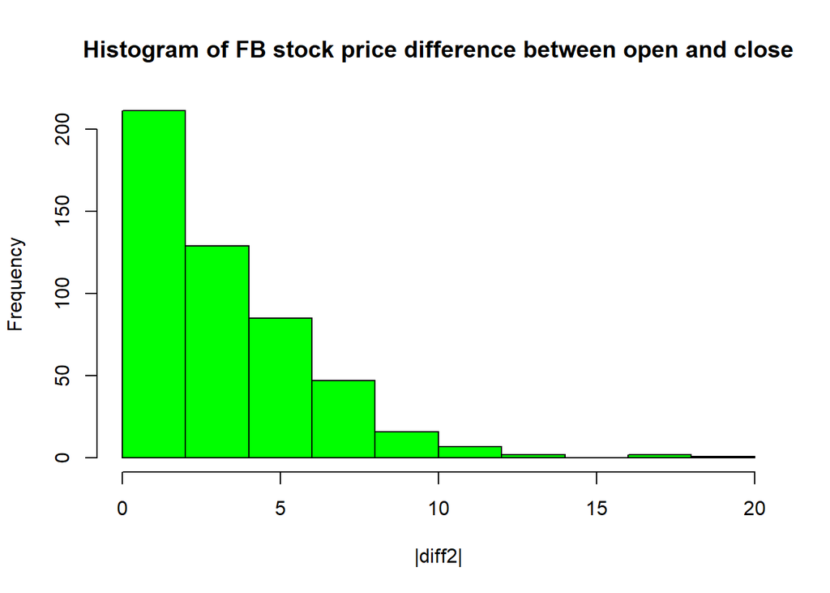

```r
hist(fbStock_df$diff2, main = paste("Histogram of FB stock price difference between open and close"), xlab = "|diff2|", col = "green")
```

### Create the scatter plot for Apple stock and FB stock prices between diff1 and volume.

From the two scatter plots of Apple and FB stock price differences (|diff1|) between highest and lowest by volume, we can see there is a pretty good linear relationship between absolute value of diff1 (|diff1|) and volume. with the stock volume getting bigger, the stock differences for Apple and FB between highest and lowest are getting higher.

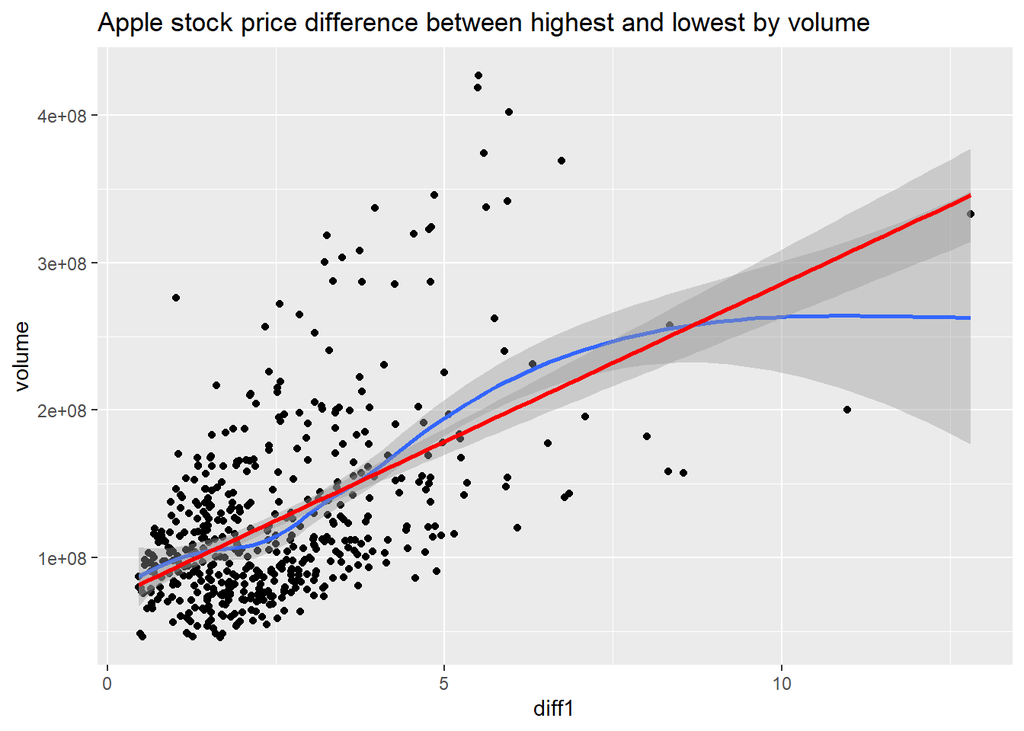

```r
plot2_APPL <- ggplot(applStock_df, aes(x= diff1, y=volume)) +
               geom_point() +
               geom_smooth() +
               geom_smooth(method = lm, col = "Red") +
               ggtitle("Apple stock price difference between highest and lowest by volume")



plot2_APPL
```

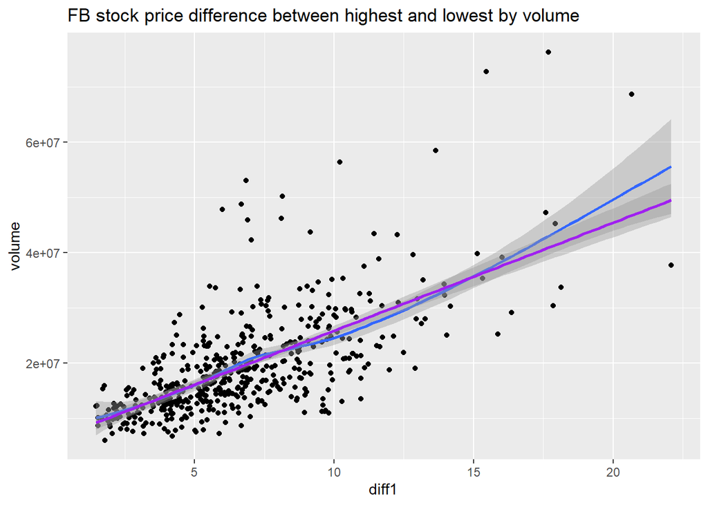

```r
plot2_FB <- ggplot(fbStock_df, aes(x= diff1, y=volume)) +
               geom_point() +
               geom_smooth() +
               geom_smooth(method = lm, col = "purple") +
               ggtitle("FB stock price difference between highest and lowest by volume")



plot2_FB
```